# $\color{red}{\text{Belkin red}}$ " vs. "$\color{blue}{\text{Elago blue}}$

Exploratory Data Analysis

Murilo Miranda

2020-February-04

# Loading data

The data has empty values and the columns are separated by semicolon. **read.csv2** function was used because it has semi-colon as default sep-argument. To solve the problem with empty values, na.strings argument was used with empty value and single space.

```
'data.frame':   15000 obs. of  7 variables:
 $ salary : num  113771 139183 101967 71761 124203 ...
 $ age    : int  59 67 53 26 46 46 34 67 71 43 ...
 $ elevel : int  3 3 2 2 3 2 2 3 2 3 ...
 $ car    : int  14 16 3 8 9 5 19 4 19 20 ...
 $ zipcode: int  6 5 8 5 0 6 8 1 4 1 ...
 $ credit : num  738 679 603 654 627 ...
 $ brand  : Factor w/ 2 levels "Belkin","Elago": 1 2 1 1 NA 2 2 NA 1 NA ...
```

# Preprocessing

## Check data types

In the data-set elevel, car and zipcode are integers. In reality, they are categorical variables, so they are converted into factor. The missing values are converted into ‘No Response’.

## Data conversions

```
'data.frame':   15000 obs. of  7 variables:
 $ salary : num  113771 139183 101967 71761 124203 ...
 $ age    : int  59 67 53 26 46 46 34 67 71 43 ...
 $ elevel : Factor w/ 4 levels "1","2","3","4": 3 3 2 2 3 2 2 3 2 3 ...
 $ car    : Factor w/ 20 levels "1","2","3","4",..: 14 16 3 8 9 5 19 4 19 20 ...
 $ zipcode: Factor w/ 9 levels "0","1","2","3",..: 7 6 9 6 1 7 9 2 5 2 ...
 $ credit : num  738 679 603 654 627 ...
 $ brand  : Factor w/ 3 levels "No Response",..: 2 3 2 2 1 3 3 1 2 1 ...
```

## Check duplicate observations

```
[1] 0
```

## Correlation between variables

```
            salary         age      credit
salary 1.000000000 0.006923108 0.794831141
age    0.006923108 1.000000000 0.004495574
credit 0.794831141 0.004495574 1.000000000
```

### Are missing values at random?

A method I use is a shadow matrix, in which the data-set consists of indicator features where a 0 is given if a value is present, and 1 if it isn’t. Correlating these with each other and the original data can help determine if features tend to be missing together (missing at random - MAR) or not (missing completely at random - MCAR).

I selected the features with numerical values, then their correlations were verified.

```
       No Response
salary  0.08712544
age     0.00154928
credit  0.05358501
```

The correlations shows that they are missing at random.

# Distributions of the variables

### Data Frame Summary

**data**  
**Dimensions:** 15000 x 7  
**Duplicates:** 0

| No | Variable | Stats / Values | Freqs (% of Valid) | Graph | Missing |
| --- | --- | --- | --- | --- | --- |
| 1 | salary [numeric] | Mean (sd) : 87233.6 (37925.2) min < med < max: 19582.9 < 87244 < 161748 IQR (CV) : 65426.1 (0.4) | 14757 distinct values |  | 0 (0%) |
| 2 | age [integer] | Mean (sd) : 49.8 (17.6) min < med < max: 20 < 50 < 80 IQR (CV) : 30 (0.4) | 61 distinct values |  | 0 (0%) |
| 3 | elevel [factor] | 1. 1 2. 2 3. 3 4. 4 | 1991 (13.3%) 6584 (43.9%) 5416 (36.1%) 1009 ( 6.7%) |  | 0 (0%) |
| 4 | car [factor] | 1. 1 2. 2 3. 3 4. 4 5. 5 6. 6 7. 7 8. 8 9. 9 10. 10 [ 10 others ] | 966 ( 6.4%) 415 ( 2.8%) 1293 ( 8.6%) 640 ( 4.3%) 658 ( 4.4%) 611 ( 4.1%) 1082 ( 7.2%) 1121 ( 7.5%) 398 ( 2.7%) 643 ( 4.3%) 7173 (47.8%) |  | 0 (0%) |
| 5 | zipcode [factor] | 1. 0 2. 1 3. 2 4. 3 5. 4 6. 5 7. 6 8. 7 9. 8 | 1626 (10.8%) 1615 (10.8%) 1670 (11.1%) 1642 (10.9%) 1688 (11.2%) 1681 (11.2%) 1709 (11.4%) 1662 (11.1%) 1707 (11.4%) |  | 0 (0%) |
| 6 | credit [numeric] | Mean (sd) : 638.9 (86.7) min < med < max: 423.7 < 638.3 < 849 IQR (CV) : 125.9 (0.1) | 11999 distinct values |  | 0 (0%) |
| 7 | brand [factor] | 1. No Response 2. Belkin 3. Elago | 5000 (33.3%) 4652 (31.0%) 5348 (35.6%) |  | 0 (0%) |

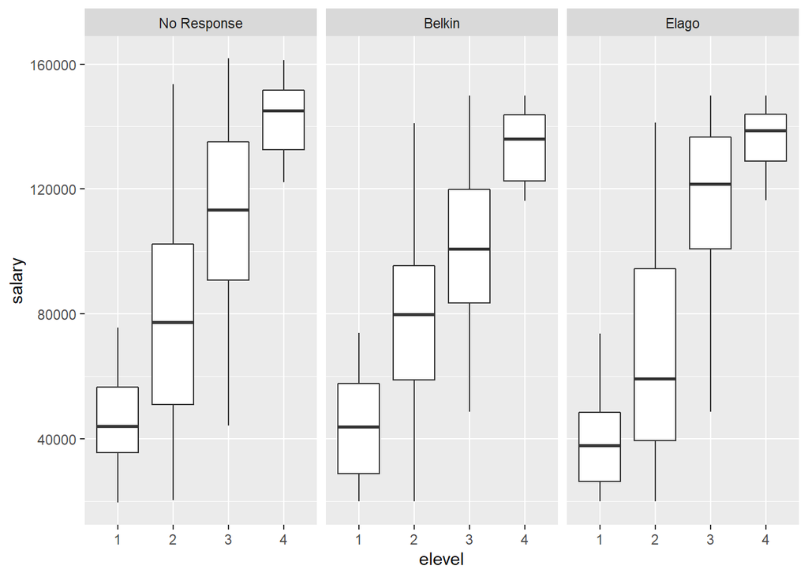

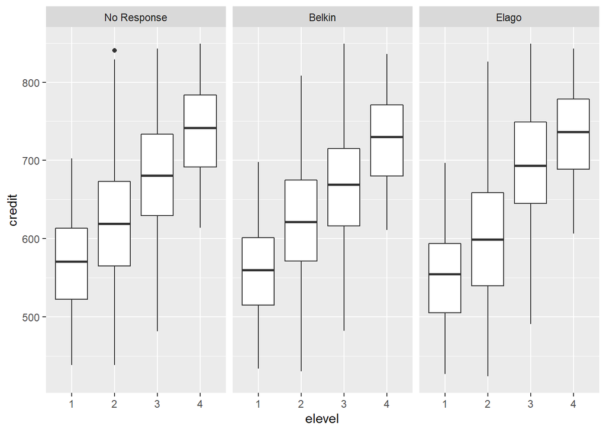

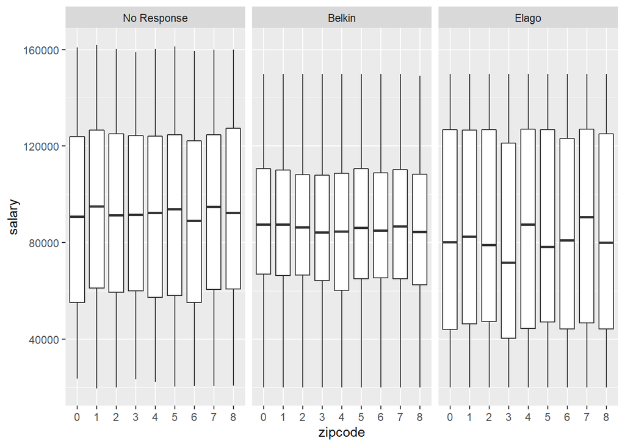

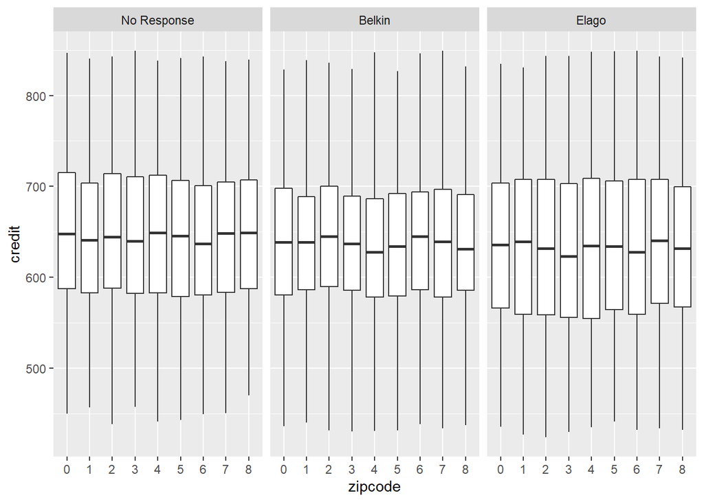

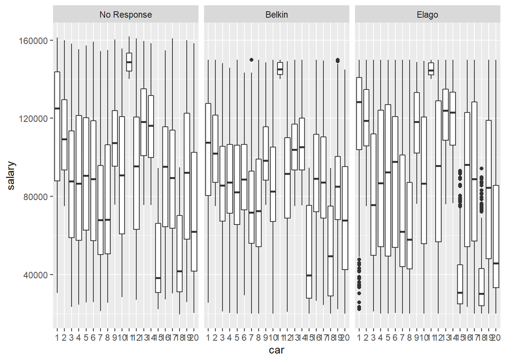

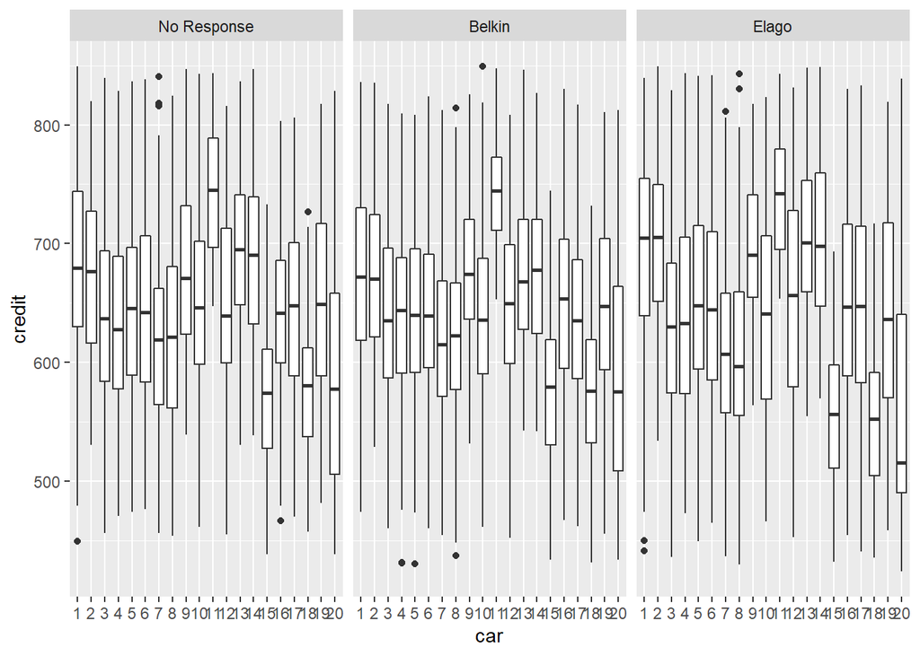

## Salary distribution by brand preference

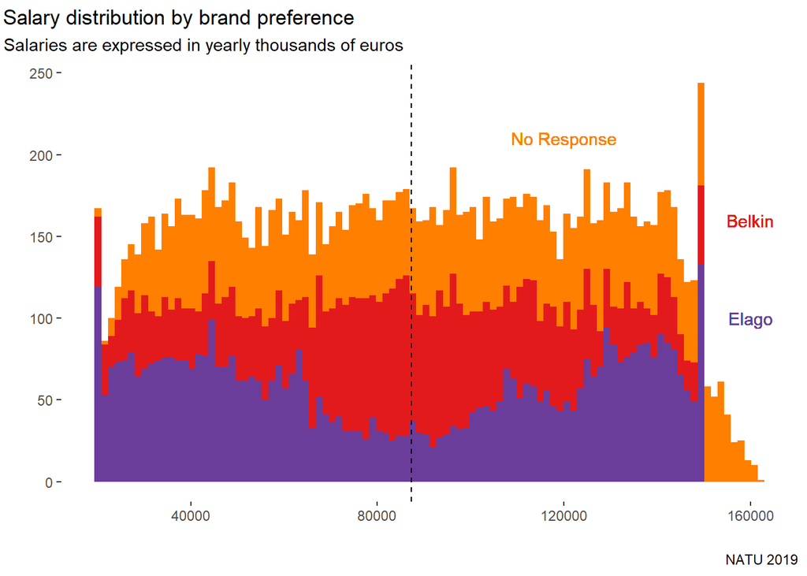

# Remove **No Response** observations in brand variable

## Age and salary are discretized

```
     salary            age        elevel        car          zipcode
 Min.   : 20000   Min.   :20.00   1:1435   3      : 846   6      :1167
 1st Qu.: 52109   1st Qu.:35.00   2:4404   8      : 759   8      :1144
 Median : 84969   Median :50.00   3:3497   20     : 740   2      :1125
 Mean   : 84897   Mean   :49.81   4: 664   7      : 719   5      :1113
 3rd Qu.:117168   3rd Qu.:65.00            15     : 643   4      :1103
 Max.   :150000   Max.   :80.00            1      : 632   0      :1097
                                           (Other):5661   (Other):3251
     credit         brand        ageCat        salCat
 Min.   :423.7   Belkin:4652   young:3464   low   :3311
 1st Qu.:572.6   Elago :5348   adult:3288   middle:3348
 Median :635.5                 old  :3248   high  :3341
 Mean   :635.6
 3rd Qu.:699.5
 Max.   :849.0
```

```
            salary         age      credit
salary 1.000000000 0.007025207 0.799999892
age    0.007025207 1.000000000 0.002744687
credit 0.799999892 0.002744687 1.000000000
```

## Comparing some features with and without NA’s

[output not shown]

# Distributions of the variables

## Brand effect

### Age

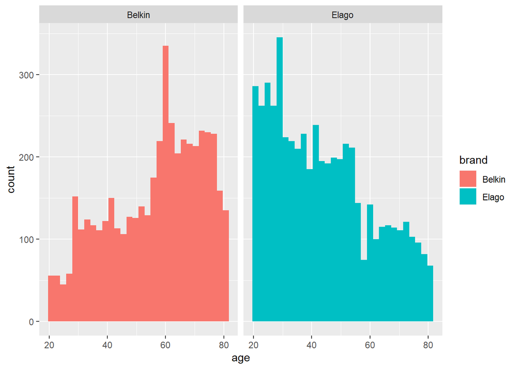

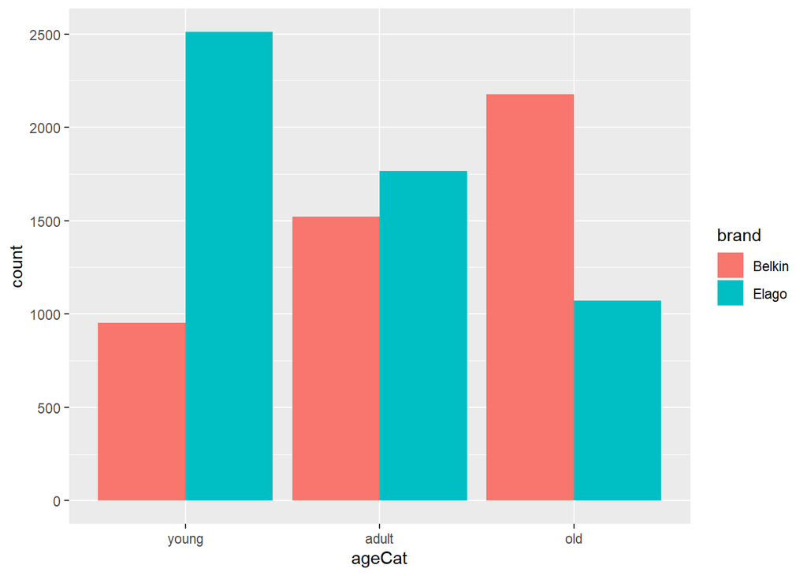

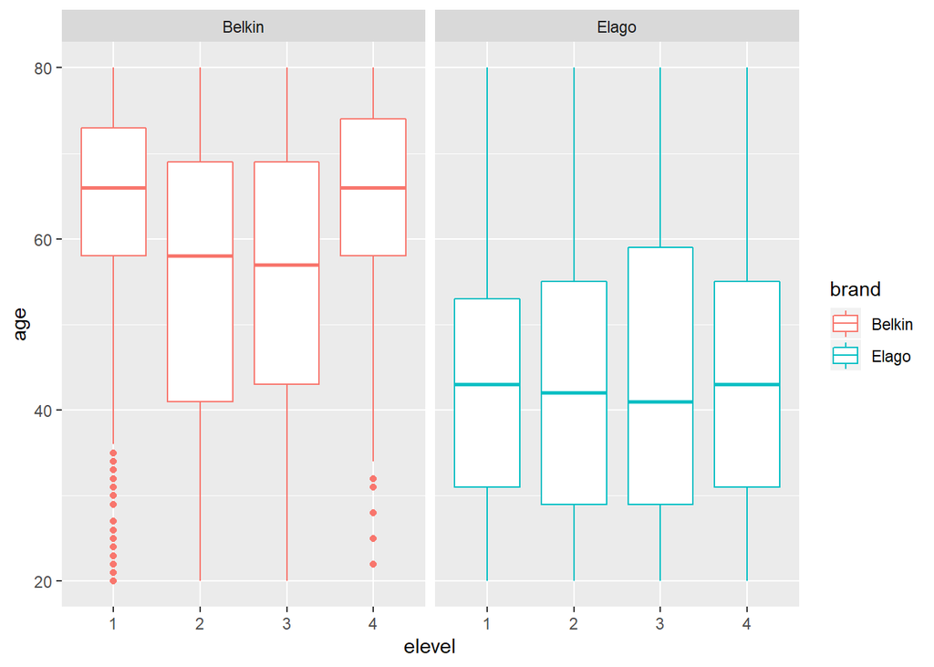

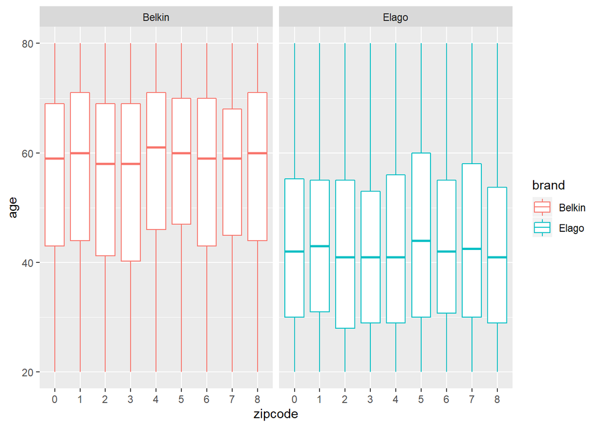

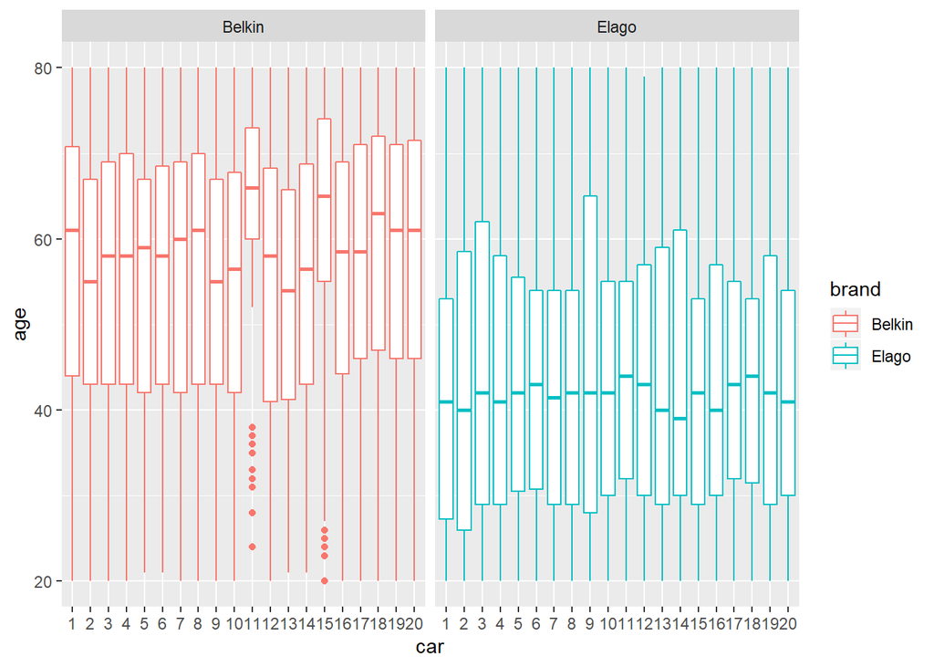

### Salary

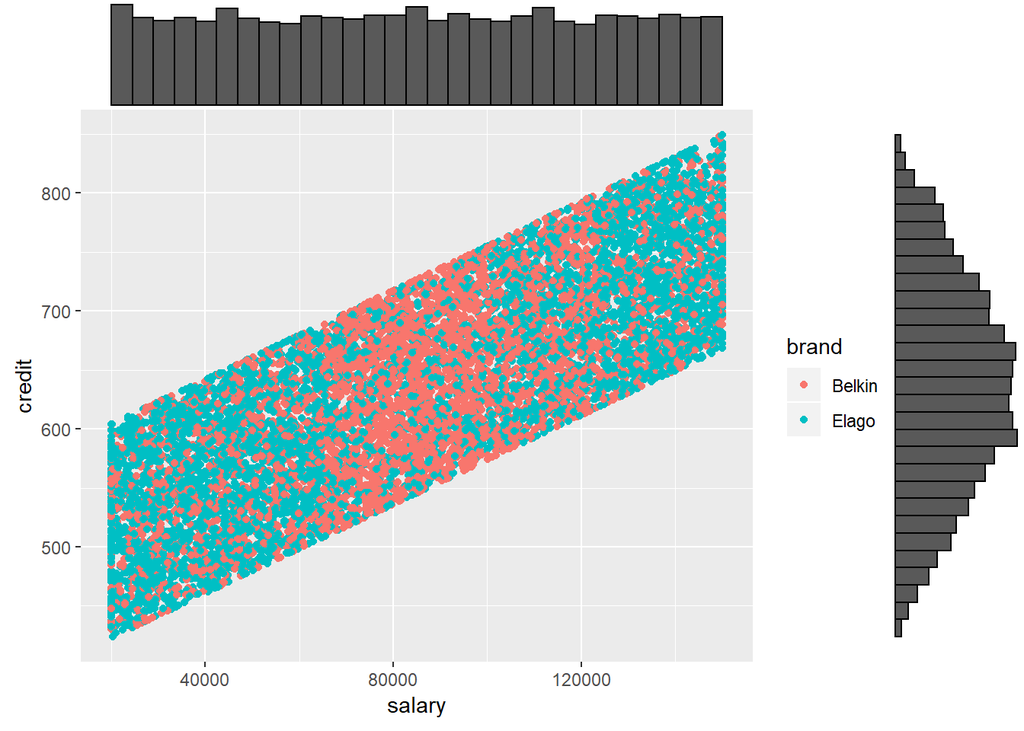

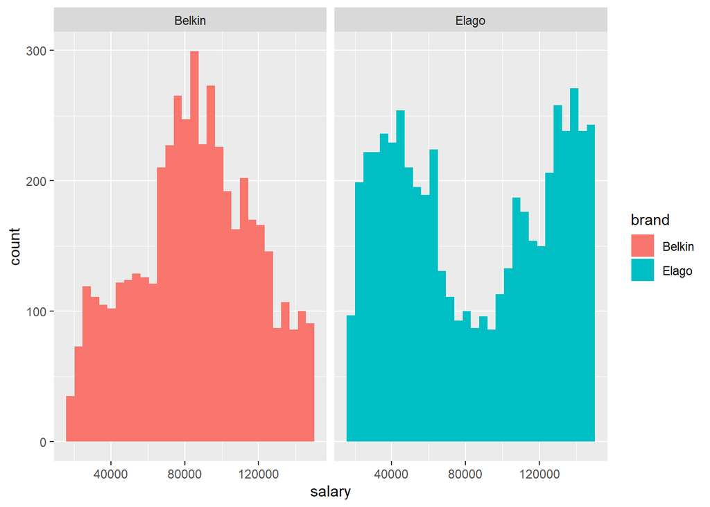

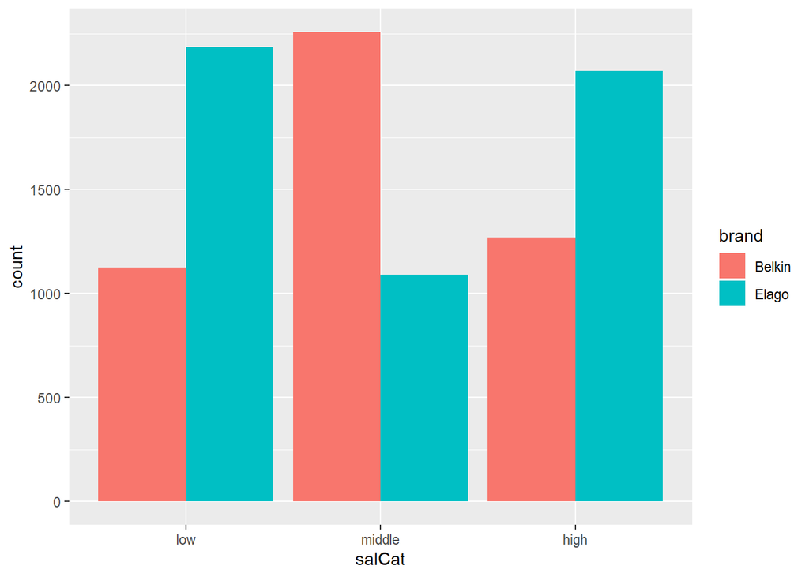

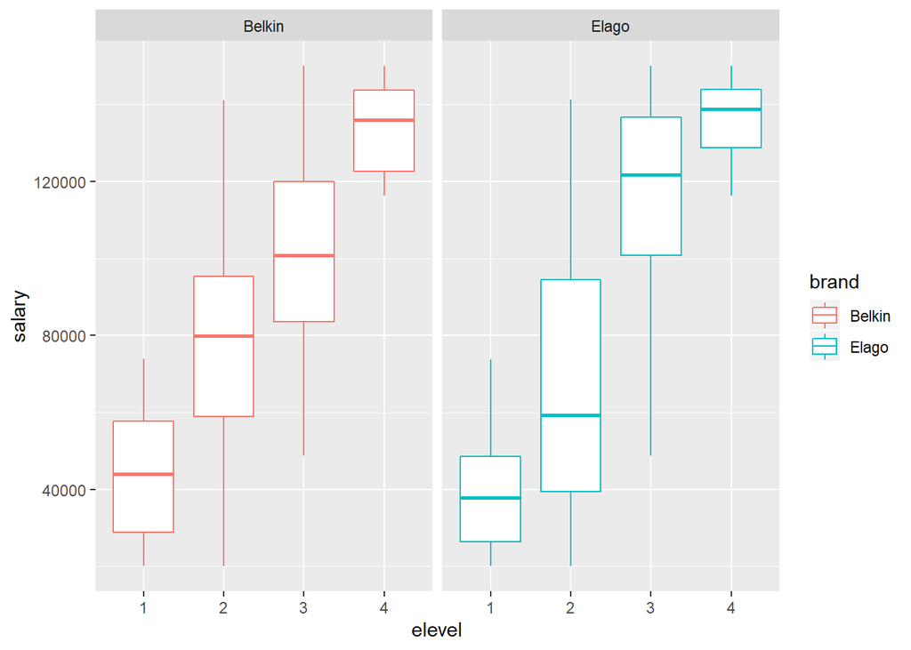

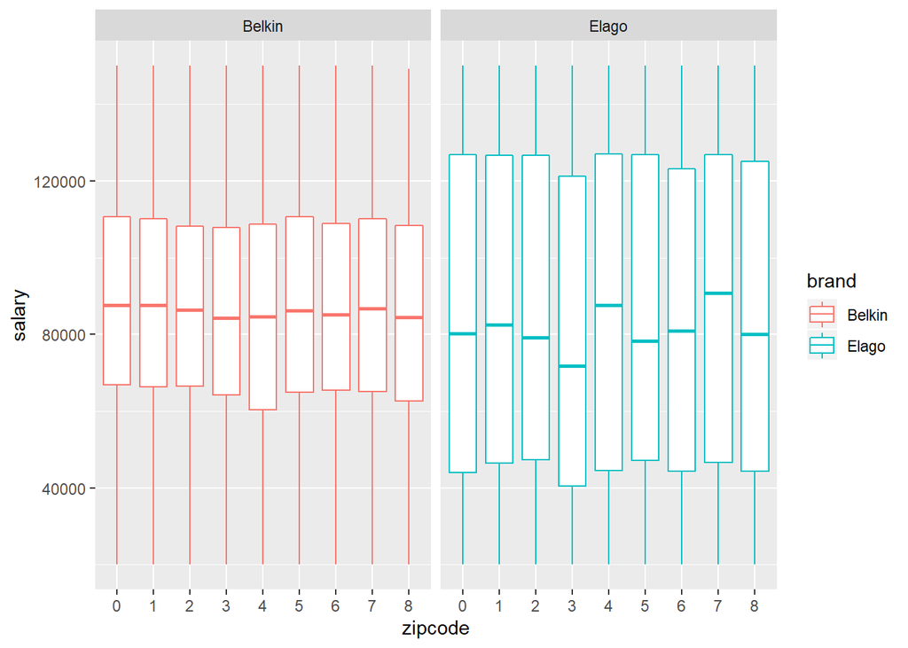

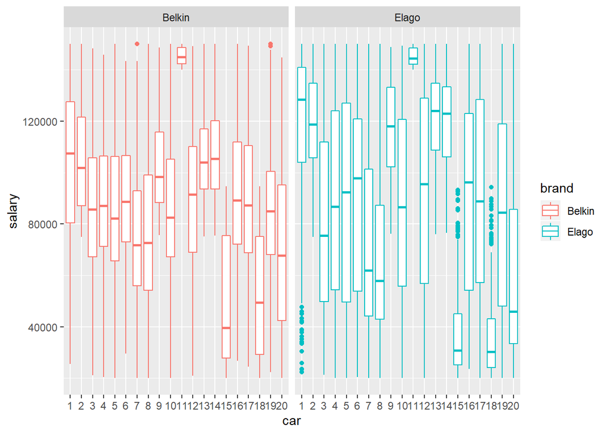

### Credit

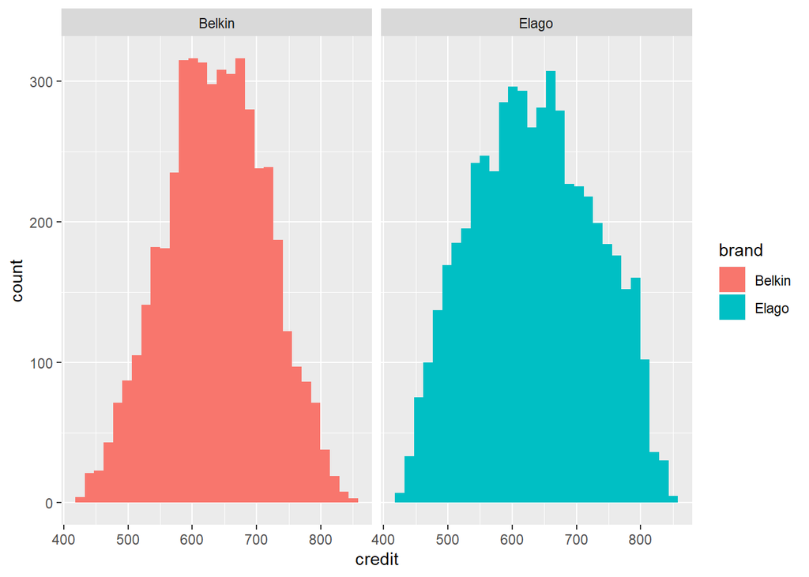

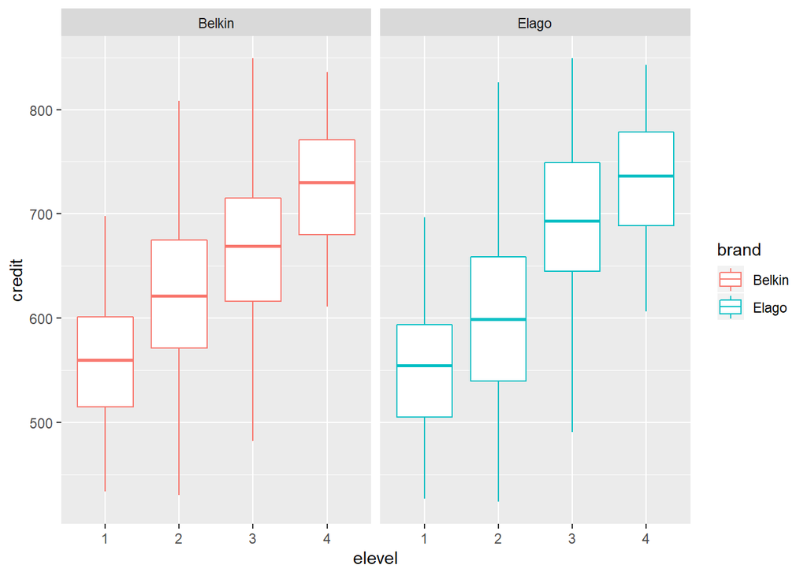

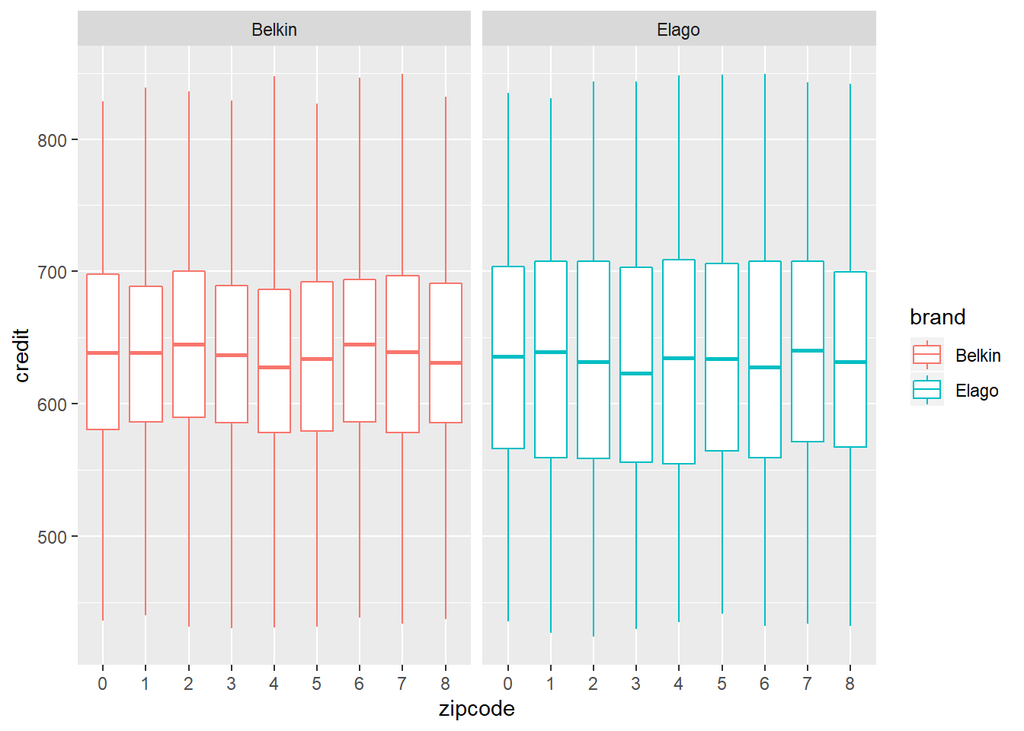

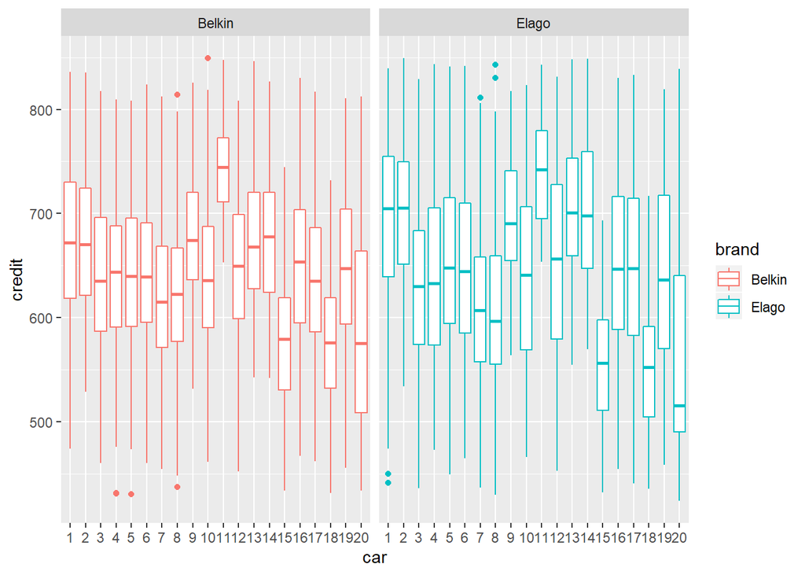

## Education level effect

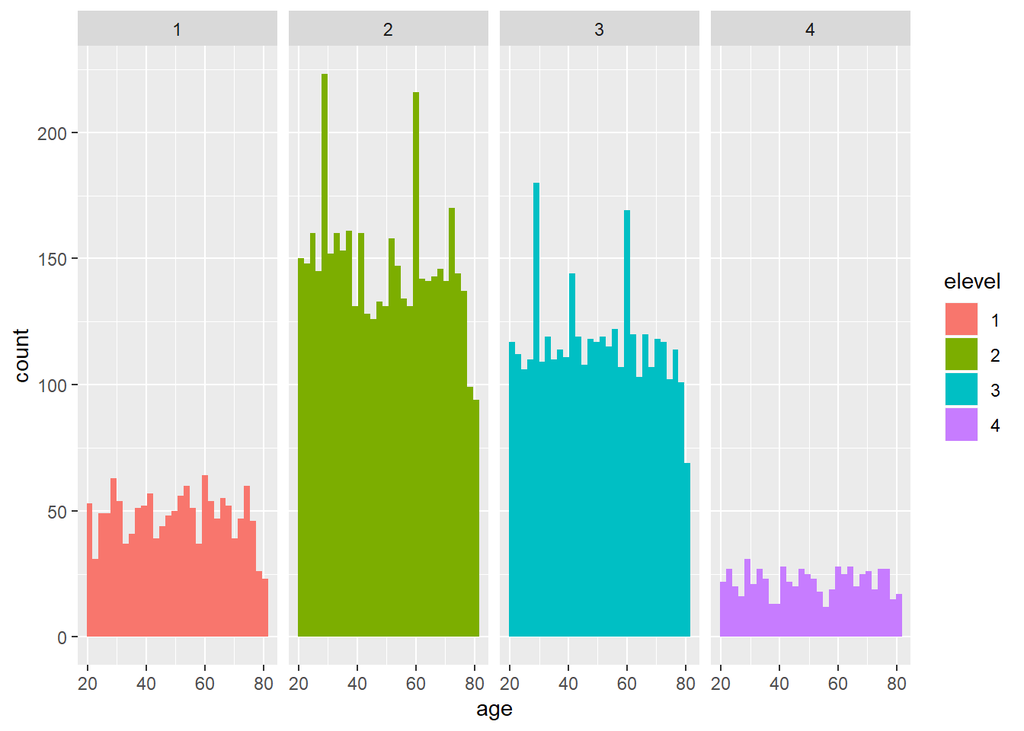

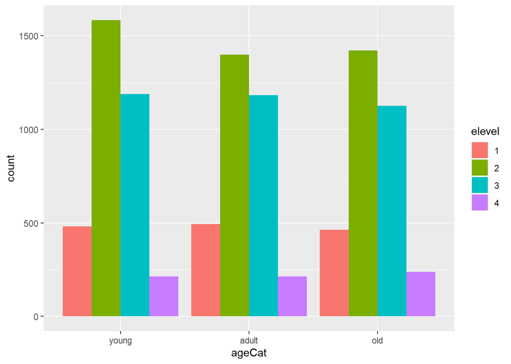

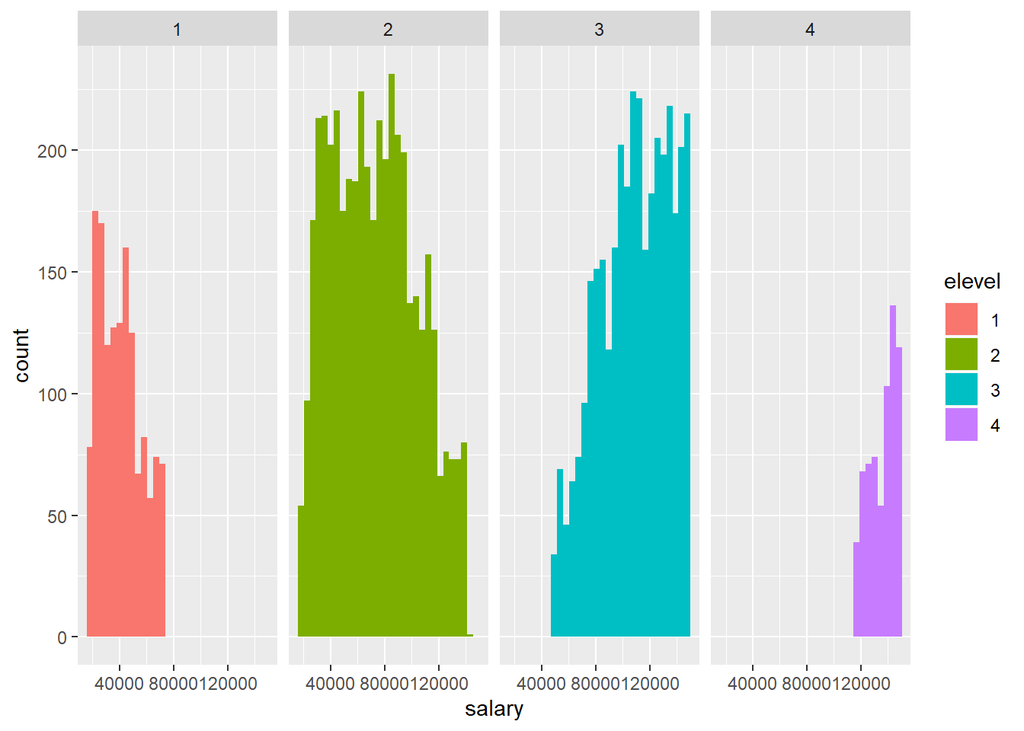

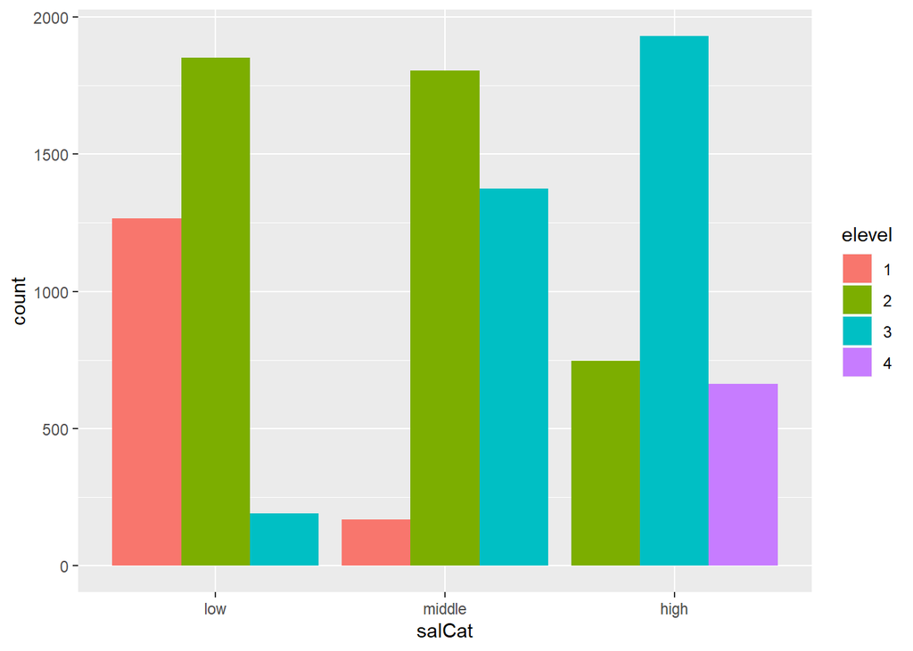

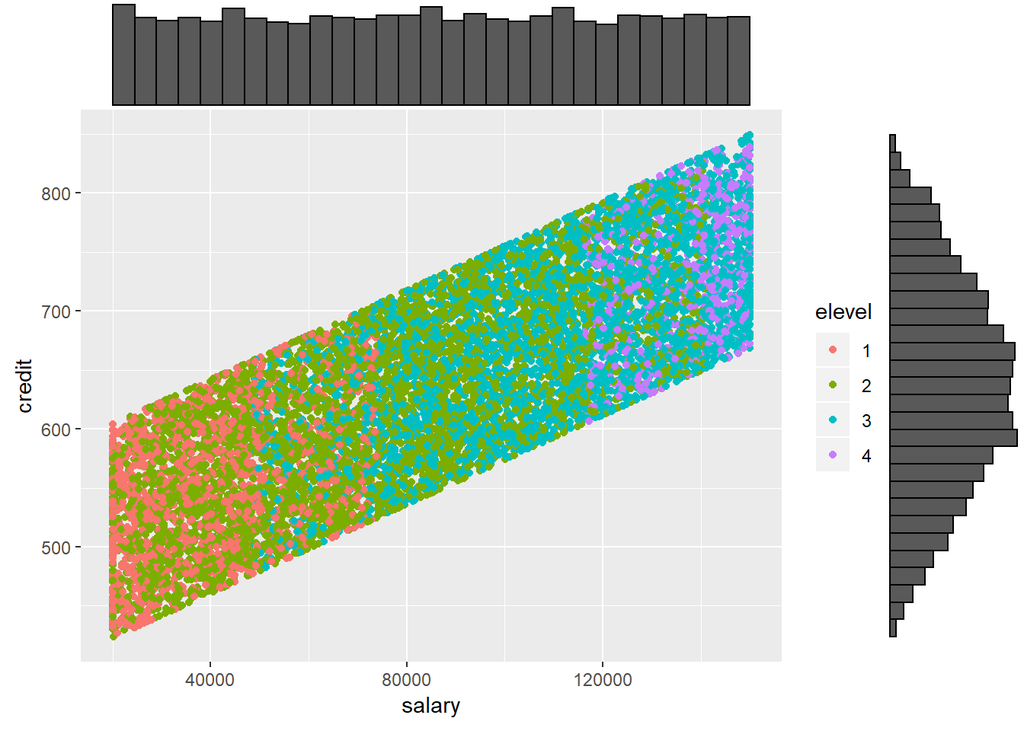

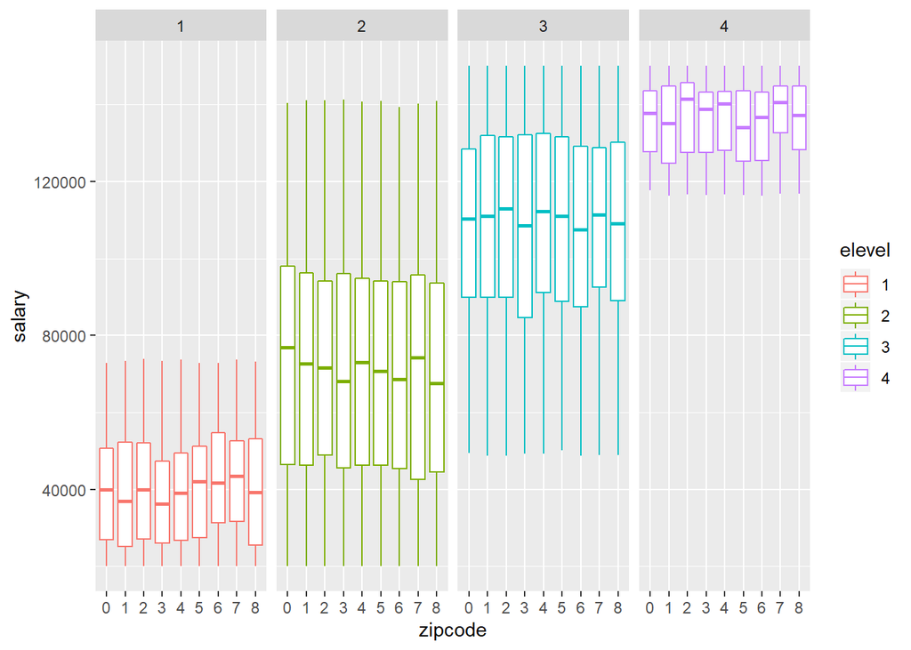

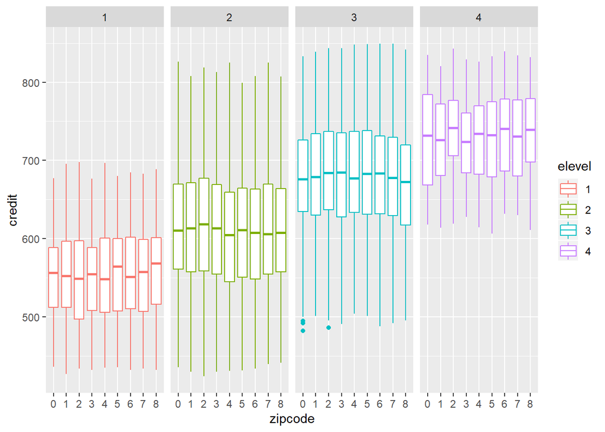

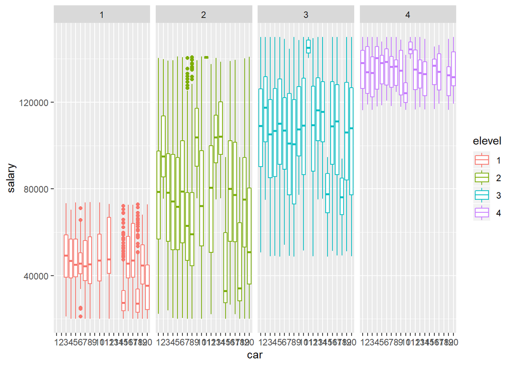

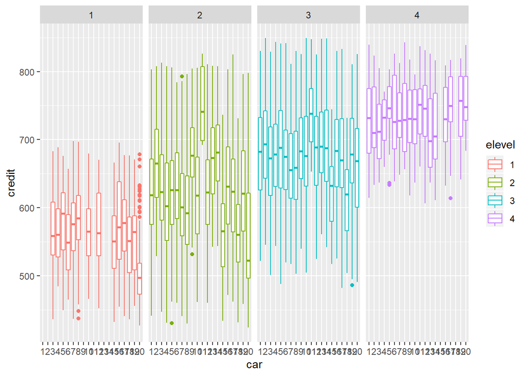

## Models

H: higher education level and age, higher salary

```
Call:
lm(formula = salary ~ age + elevel, data = dataSet)

Residuals:
   Min     1Q Median     3Q    Max
-59979 -18705    235  18691  68818

Coefficients:
             Estimate Std. Error t value Pr(>|t|)
(Intercept) 40841.839   1033.818  39.506   <2e-16 ***
age             4.754     15.142   0.314    0.754
elevel2     31503.426    809.800  38.903   <2e-16 ***
elevel3     67663.594    835.180  81.017   <2e-16 ***
elevel4     94616.334   1250.393  75.669   <2e-16 ***
---
Signif. codes:  0 '***' 0.001 '**' 0.01 '*' 0.05 '.' 0.1 ' ' 1

Residual standard error: 26640 on 9995 degrees of freedom
Multiple R-squared:  0.5011,    Adjusted R-squared:  0.5009
F-statistic:  2510 on 4 and 9995 DF,  p-value: < 2.2e-16
```

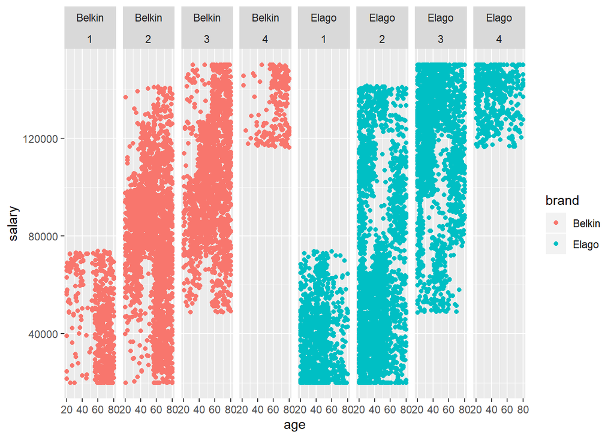

H: higher salary, higher credit

```
Call:
lm(formula = credit ~ salary, data = dataSet)

Residuals:
    Min      1Q  Median      3Q     Max
-92.152 -46.231   0.301  45.489  92.715

Coefficients:
             Estimate Std. Error t value Pr(>|t|)
(Intercept) 4.783e+02  1.291e+00   370.5   <2e-16 ***
salary      1.853e-03  1.390e-05   133.3   <2e-16 ***
---
Signif. codes:  0 '***' 0.001 '**' 0.01 '*' 0.05 '.' 0.1 ' ' 1

Residual standard error: 52.41 on 9998 degrees of freedom
Multiple R-squared:   0.64, Adjusted R-squared:   0.64
F-statistic: 1.777e+04 on 1 and 9998 DF,  p-value: < 2.2e-16
```

# Conclusion

Age and salary are uniformly distributed and credit is normally distributed. Salary and credit have a high correlation (rho = 0.795). They are also correlated with education level, that is, people with a high level of education receive high salary and credit in banks and people with a low level of education receive low salary and credit. Car models 11 are generally more common with people with higher incomes, and car models 18 and 15 with people with lower incomes.

There are more people at educational level 2, followed by level 3, level 1 and, finally, level 4. Age at educational level is equally distributed.

Older people and people with intermediate income are associated with the Belkin brand and younger people and people with low or high income are associated with the Elago brand.